# Análisis de la Esperanza de Vida en Diferentes Regiones del Mundo

##### Histograma:

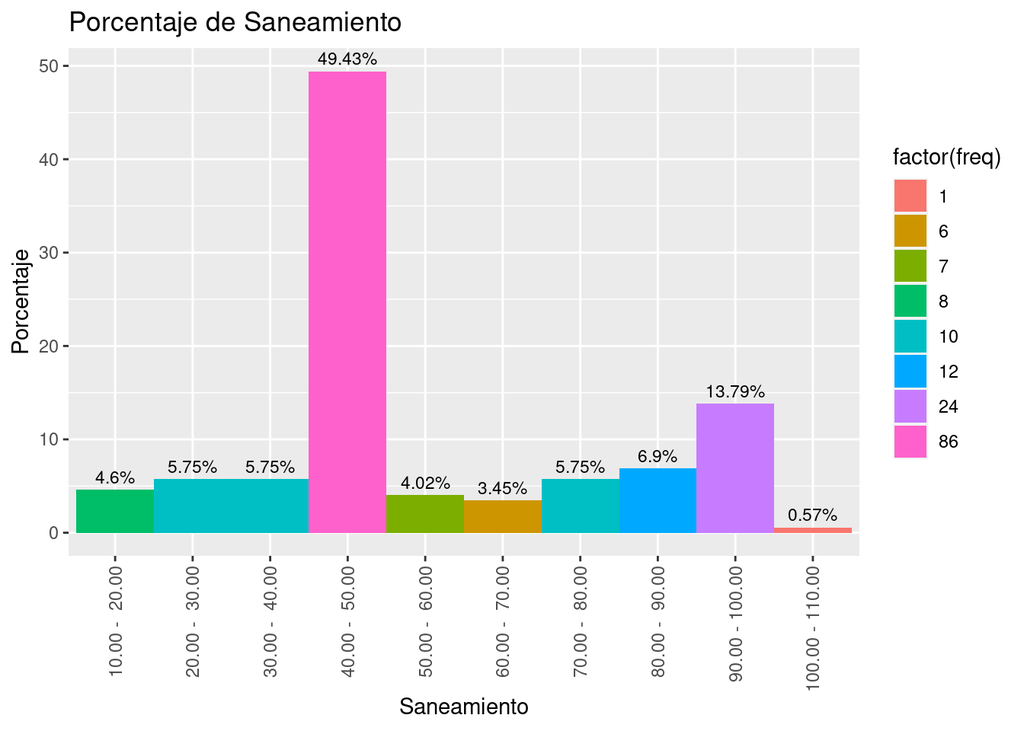

```r
generar_histograma(df, "Sanitation", "Saneamiento", "Porcentaje de Saneamiento")
```

#### Esperanza De Vida

La esperanza de vida al nacer es un indicador fundamental para evaluar la salud de una población y su evolución en el tiempo. En la base de datos original, la esperanza de vida presenta una media de 72.18784 años, una mediana de 73.414 años y una desviación estándar de 7.662378 años. Estos valores indican que, en promedio, la esperanza de vida es cercana a los 72 años, con una tendencia hacia los 73 años. La baja desviación estándar sugiere que los datos están relativamente agrupados en torno a la media, lo que implica una estabilidad en la esperanza de vida a en nuestras regiones. En el contexto de este estudio, se destaca que la esperanza de vida es considerablemente alta en nuestras regiones.

##### Base de datos original:

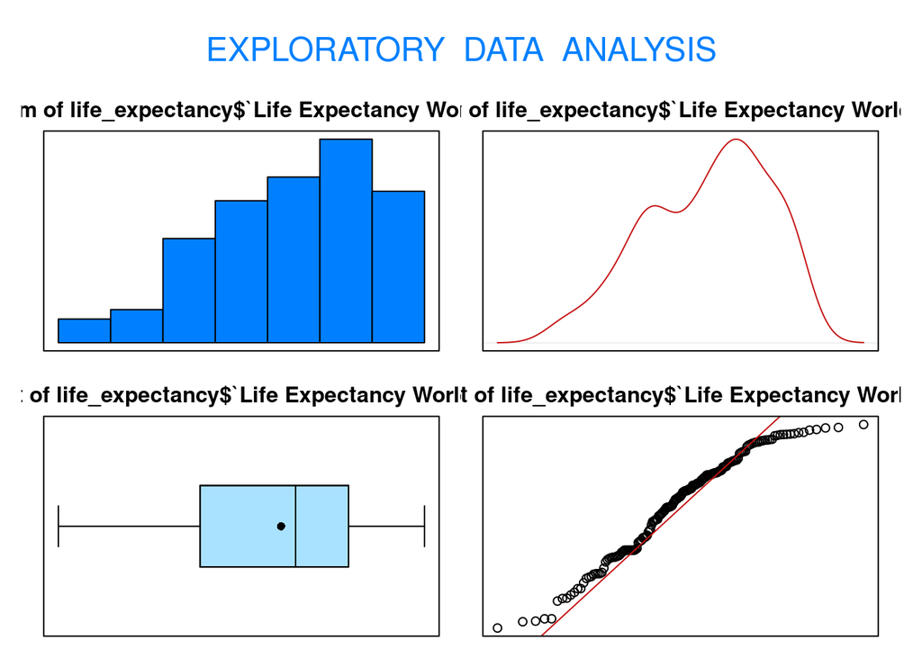

```
## Size (n)  Missing  Minimum   1st Qu     Mean   Median   TrMean   3rd Qu
##  174.000    0.000   53.283   65.347   72.188   73.414   72.456   77.909
##      Max    Stdev      Var  SE Mean   I.Q.R.    Range Kurtosis Skewness
##   84.356    7.662   58.712    0.581   12.562   31.073   -0.702   -0.420
## SW p-val
##    0.000
```

```r
eda(life_expectancy$`Life Expectancy World Bank`)
```

##### Base de datos limpia:

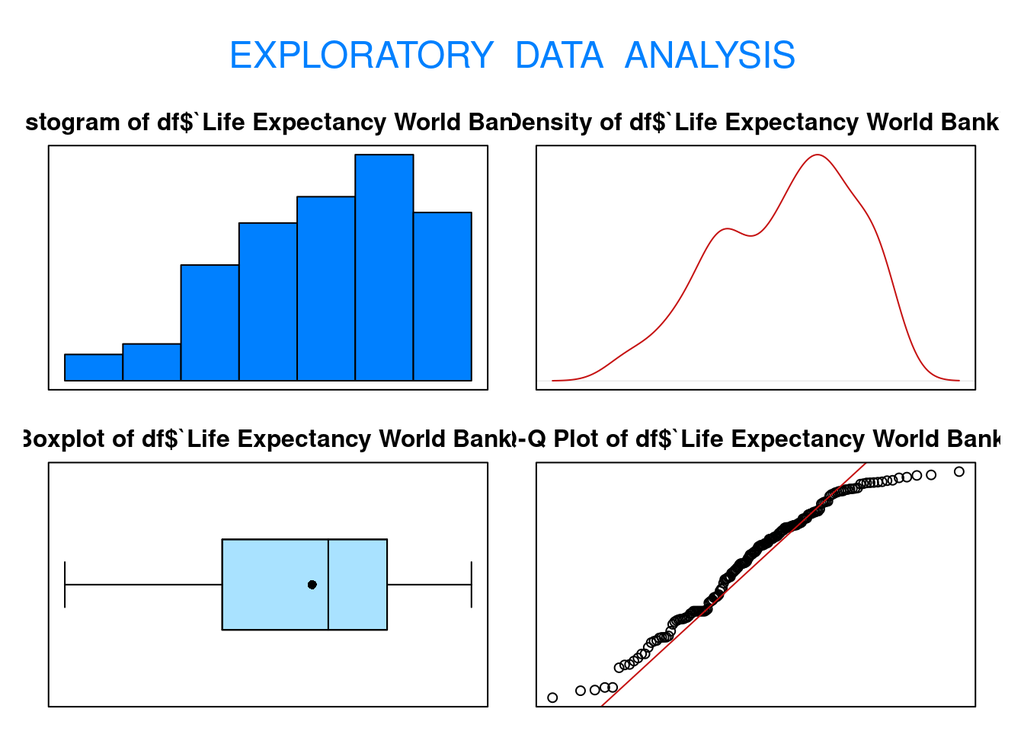

```
## Size (n)  Missing  Minimum   1st Qu     Mean   Median   TrMean   3rd Qu
##  174.000    0.000   53.283   65.347   72.188   73.414   72.456   77.909
##      Max    Stdev      Var  SE Mean   I.Q.R.    Range Kurtosis Skewness
##   84.356    7.662   58.712    0.581   12.562   31.073   -0.702   -0.420
## SW p-val
##    0.000
```

```r
eda(df$`Life Expectancy World Bank`)
```

##### Tabla de frecuencia

```r
print(generar_tabla_frecuencias(df, "Life Expectancy World Bank"))
```

```
##       Intervalo Frecuencia.Absoluta Frecuencia.Relativa....
## 1 50.00 - 55.00                   5                2.873563
## 2 55.00 - 60.00                   7                4.022989
## 3 60.00 - 65.00                  22               12.643678
## 4 65.00 - 70.00                  30               17.241379
## 5 70.00 - 75.00                  35               20.114943
## 6 75.00 - 80.00                  43               24.712644
## 7 80.00 - 85.00                  32               18.390805
##   Frecuencia.Acumulada Frecuencia.Relativa.Acumulada....
## 1                    5                          2.873563
## 2                   12                          6.896552
## 3                   34                         19.540230
## 4                   64                         36.781609
## 5                   99                         56.896552
## 6                  142                         81.609195
## 7                  174                        100.000000
```

##### Histograma:

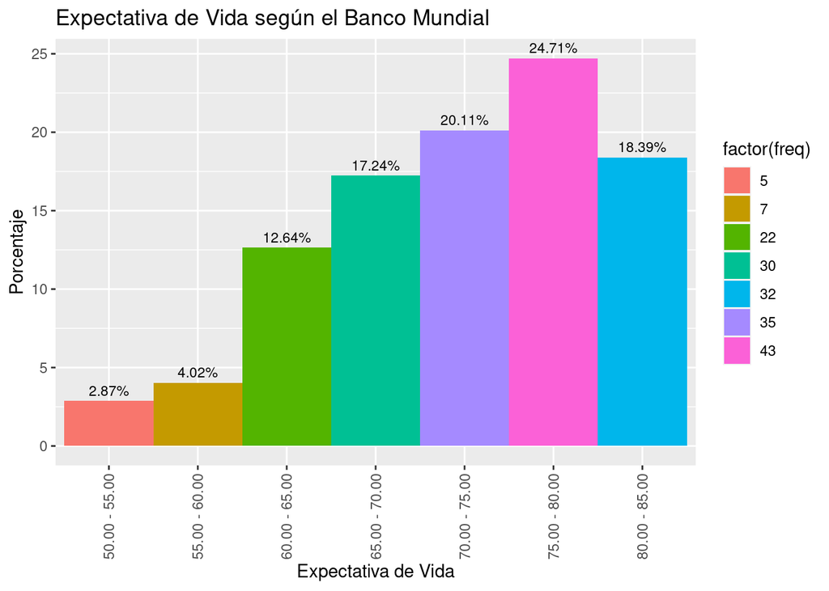

```r
generar_histograma(df, "Life Expectancy World Bank", "Expectativa de Vida", "Expectativa de Vida según el Banco Mundial")
```

### Variables cualitativas:

##### Tabla cruzada de Grupo de ingreso Vs Corrupción:

Cuando se analiza la siguiente tabla cruzada que establece la relación entre el grupo de ingreso vs la corrupción, se observa que a medida que el grupo de ingreso es mejor, es decir de “upper middle income” en adelante, la frecuencia de corrupción menor a “3” en el ranking tiende a disminuir.

```r
tablaCruzada <- CrossTable(life_expectancy$IncomeGroup, life_expectancy$Corruption, prop.r = TRUE, prop.c = TRUE, prop.chisq = FALSE)

print(tablaCruzada)
```

```
##    Cell Contents
## |-------------------------|
## |                       N |
## |           N / Row Total |
## |           N / Col Total |
## |         N / Table Total |
## |-------------------------|
##
## ============================================================================================
##                                life_expectancy$Corruption
## life_expectancy$IncomeGroup      1.5       2     2.5       3     3.5       4     4.5   Total
## --------------------------------------------------------------------------------------------
## High income                        0       0       0      57       0       0       0      57
##                                0.000   0.000   0.000   1.000   0.000   0.000   0.000   0.328
##                                0.000   0.000   0.000   0.442   0.000   0.000   0.000
##                                0.000   0.000   0.000   0.328   0.000   0.000   0.000
## --------------------------------------------------------------------------------------------
## Low income                         4       2      10       5       2       0       0      23
##                                0.174   0.087   0.435   0.217   0.087   0.000   0.000   0.132
##                                0.800   0.667   0.455   0.039   0.182   0.000   0.000
##                                0.023   0.011   0.057   0.029   0.011   0.000   0.000
## --------------------------------------------------------------------------------------------
## Lower middle income                1       1      11      24       6       1       1      45
##                                0.022   0.022   0.244   0.533   0.133   0.022   0.022   0.259
##                                0.200   0.333   0.500   0.186   0.545   0.333   1.000
##                                0.006   0.006   0.063   0.138   0.034   0.006   0.006
## --------------------------------------------------------------------------------------------
## Upper middle income                0       0       1      43       3       2       0      49
##                                0.000   0.000   0.020   0.878   0.061   0.041   0.000   0.282
##                                0.000   0.000   0.045   0.333   0.273   0.667   0.000
##                                0.000   0.000   0.006   0.247   0.017   0.011   0.000
## --------------------------------------------------------------------------------------------
## Total                              5       3      22     129      11       3       1     174
##                                0.029   0.017   0.126   0.741   0.063   0.017   0.006
## ============================================================================================
```

##### Tabla cruzada de Región Vs Ingreso:

De la relación entre las tablas se puede resaltar que los países con “Low income” están casi en su totalidad en la región de Sub Saharan Africa, además de que la región del norte de américa está dominda por el grupo de high income, sin embargo, esto se debe a la poca representación de paises de la zona, solo tres países en dicho lugar.Además,la mayor representación de los países de ingresos altos son de la zonade Europa y Asia central.

```r
tablaCruzada <- CrossTable(life_expectancy$Region, life_expectancy$IncomeGroup, prop.r = TRUE, prop.c = TRUE, prop.chisq = FALSE)

print(tablaCruzada)
```

```
##    Cell Contents
## |-------------------------|
## |                       N |
## |           N / Row Total |
## |           N / Col Total |
## |         N / Table Total |
## |-------------------------|
##
## ==============================================================================
##                 life_expectancy$IncomeGroup
## lf_xpctncy$R    High income   Low income   Lwr mddl inc   Uppr mddl in   Total
## ------------------------------------------------------------------------------
## Est As & Pcf              7            0             11              9      27
##                       0.259        0.000          0.407          0.333   0.155
##                       0.123        0.000          0.244          0.184
##                       0.040        0.000          0.063          0.052
## ------------------------------------------------------------------------------
## Erp & Cntr A             31            0              3             13      47
##                       0.660        0.000          0.064          0.277   0.270
##                       0.544        0.000          0.067          0.265
##                       0.178        0.000          0.017          0.075
## ------------------------------------------------------------------------------
## Ltn Amrc & C              7            0              5             17      29
##                       0.241        0.000          0.172          0.586   0.167
##                       0.123        0.000          0.111          0.347
##                       0.040        0.000          0.029          0.098
## ------------------------------------------------------------------------------
## Mddl E & N A              8            0              5              3      16
##                       0.500        0.000          0.312          0.188   0.092
##                       0.140        0.000          0.111          0.061
##                       0.046        0.000          0.029          0.017
## ------------------------------------------------------------------------------
## North Americ              3            0              0              0       3
##                       1.000        0.000          0.000          0.000   0.017
##                       0.053        0.000          0.000          0.000
##                       0.017        0.000          0.000          0.000
## ------------------------------------------------------------------------------
## South Asia                0            1              6              1       8
##                       0.000        0.125          0.750          0.125   0.046
##                       0.000        0.043          0.133          0.020
##                       0.000        0.006          0.034          0.006
## ------------------------------------------------------------------------------
## Sb-Shrn Afrc              1           22             15              6      44
##                       0.023        0.500          0.341          0.136   0.253
##                       0.018        0.957          0.333          0.122
##                       0.006        0.126          0.086          0.034
## ------------------------------------------------------------------------------
## Total                    57           23             45             49     174
##                       0.328        0.132          0.259          0.282
## ==============================================================================
```

##### Region

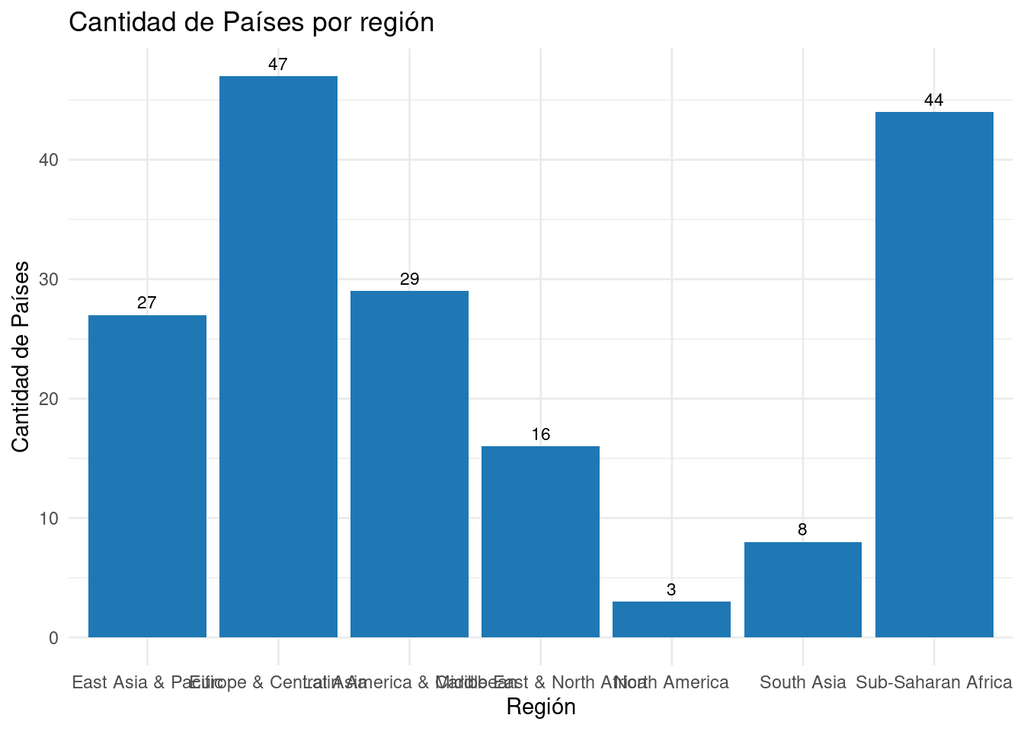

```r
resumen_paises_por_region <- life_expectancy %>%
  group_by(Region) %>%
  summarise(Cantidad_Paises = n())

# Mostrar el resumen
ggplot(resumen_paises_por_region, aes(x = factor(Region), y = Cantidad_Paises)) +
  geom_bar(stat = "identity", fill = "#1f78b4") +
  geom_text(aes(label = Cantidad_Paises), vjust = -0.5, size = 3) +
  labs(x = "Región", y = "Cantidad de Países", title = "Cantidad de Países por región") +
  theme_minimal()
```

El gráfico de barras proporcionado representa la cantidad de países en diferentes regiones del mundo. En esta interpretación:

El eje x representa las distintas regiones geográficas del mundo, que incluyen Asia Oriental y el Pacífico, Europa y Asia Central, América Latina y el Caribe, Medio Oriente y África del Norte, Asia del Sur y África Subsahariana.

El eje y representa la cantidad de países en cada región.

##### Grupo Ingreso

```r
life_expectancy$IncomeGroup <- factor(life_expectancy$IncomeGroup, levels = c("Low income", "Lower middle income", "Upper middle income", "High income"))

datos_2019 <- subset(life_expectancy, Year == 2019)

relacion_ingresos_expectativa_vida <- life_expectancy %>%
  group_by(Region, IncomeGroup) %>%
  summarise(Media_Expectativa_Vida = mean(`Life Expectancy World Bank`, na.rm = TRUE))
```

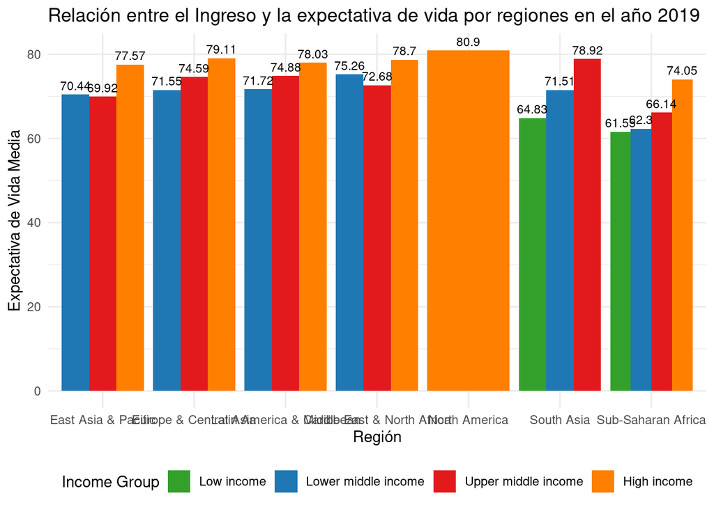

```r
ggplot(relacion_ingresos_expectativa_vida, aes(x = Region, y = Media_Expectativa_Vida, fill = IncomeGroup)) +
  geom_bar(stat = "identity", position = "dodge") +
  scale_fill_manual(values = c("#33a02c","#1f78b4" , "#e31a1c", "#ff7f00"), name = "Income Group") +
  geom_text(aes(label = round(Media_Expectativa_Vida, 2)), position = position_dodge(width = 0.9), vjust = -0.5, size = 3) +
  labs(x = "Región", y = "Expectativa de Vida Media", title = "Relación entre el Ingreso y la expectativa de vida por regiones en el año 2019") +
  theme_minimal() +
  theme(legend.position = "bottom")
```

El gráfico de barras proporcionado muestra la relación entre el grupo de ingresos y la esperanza de vida al nacer en diferentes regiones en el año 2019. En esta interpretación:

El eje y representa la esperanza de vida al nacer.

Las regiones incluidas son Asia Oriental y el Pacífico, Europa y Asia Central, América Latina y el Caribe, Medio Oriente y África del Norte, Asia del Sur y África Subsahariana.

Estos resultados sugieren una correlación positiva entre el nivel de ingresos y la esperanza de vida al nacer. En otras palabras, los países con ingresos más altos tienden a presentar una esperanza de vida al nacer más elevada en comparación con los países de ingresos más bajos.

##### Corrupción

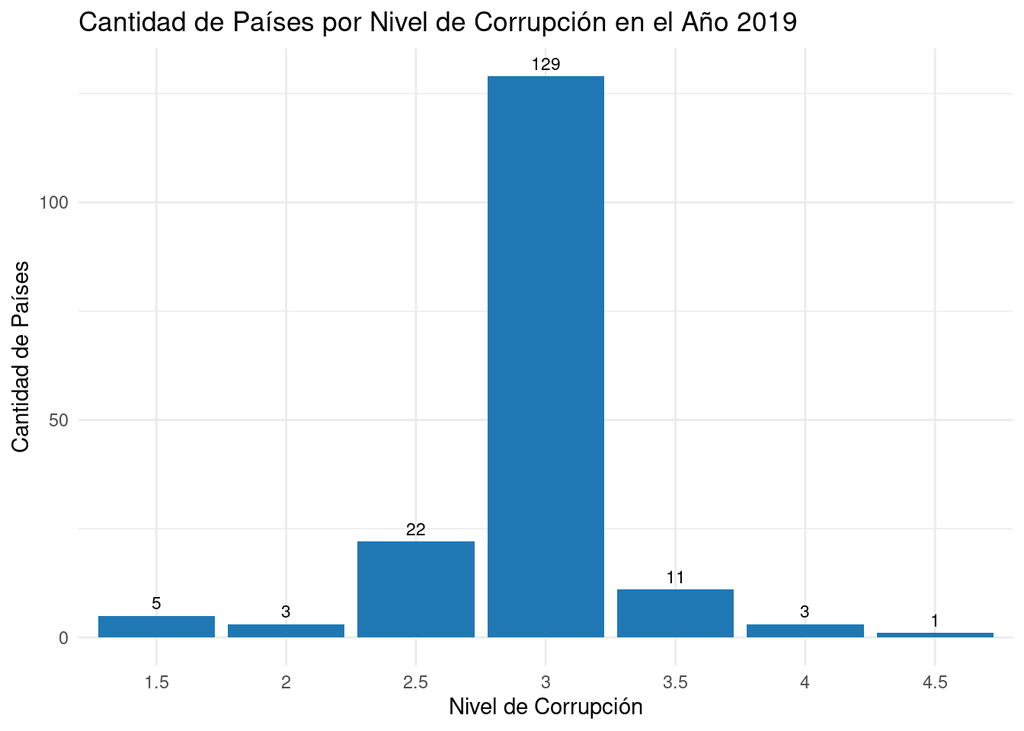

```r
cantidad_paises_por_corrupcion <- life_expectancy %>%
  group_by(Corruption) %>%
  summarise(Cantidad_Paises = n())

# Mostrar el resultado
ggplot(cantidad_paises_por_corrupcion, aes(x = factor(Corruption), y = Cantidad_Paises)) +
  geom_bar(stat = "identity", fill = "#1f78b4") +
  geom_text(aes(label = Cantidad_Paises), vjust = -0.5, size = 3) +
  labs(x = "Nivel de Corrupción", y = "Cantidad de Países",
       title = "Cantidad de Países por Nivel de Corrupción en el Año 2019") +
  theme_minimal()
```

El gráfico de barras proporcionado muestra la cantidad de países por nivel de corrupción en el año 2019. En esta interpretación:

El eje x representa los diferentes niveles de corrupción.

El eje y representa la cantidad de países en cada nivel de corrupción.

Los datos indican que el nivel de corrupción con la mayor cantidad de países es el nivel 3, con un total de 129 países. Por otro lado, el nivel de corrupción con la menor cantidad de países es el nivel 4.5, con solo 1 país.

Estos resultados destacan una variación significativa en los niveles de corrupción entre los diferentes países del mundo. Específicamente, se observa que hay una mayor cantidad de países en el nivel 3 de corrupción y una menor cantidad en el nivel 4.5.

### Estimacion muestral y estimacion proporcion:

```r
# Crear una función para calcular el intervalo de confianza para una región específica
calcular_intervalo_confianza <- function(data, region) {
  data_region <- subset(data, Region == region)

  desviacion_estandar <- sd(data_region$`Life Expectancy World Bank`)

  x <- mean(data_region$`Life Expectancy World Bank`)

  n <- nrow(data_region)

  alpha <- 1 - 0.98

  valor_critico_t <- qt(1 - alpha/2, n - 1)

  error_estandar <- desviacion_estandar / sqrt(n)

  margen_error <- valor_critico_t * error_estandar

  lim.inf <- x - margen_error
  lim.sup <- x + margen_error

  intervalo <- data.frame(n, error_estandar, x, lim.inf, lim.sup)

  return(intervalo)
}


regiones_unicas <- unique(life_expectancy$Region)

tabla_intervalos <- data.frame()

# Iterar sobre cada región y calcular el intervalo de confianza
for (region in regiones_unicas) {
  intervalo <- calcular_intervalo_confianza(life_expectancy, region)

  # Agregar la región al marco de datos
  intervalo$regiones <- region

  # Reorganizar las columnas
  intervalo <- intervalo %>%
    select(regiones, everything())

  # Unir el resultado a la tabla_intervalos
  tabla_intervalos <- bind_rows(tabla_intervalos, intervalo)
}

# Imprimir la tabla de resultados
View(tabla_intervalos)
```

## Proporciones

```r
calcular_intervalo_p <- function(data, income_group) {
  intervalo <- data %>%
    mutate(Ingresos = as.numeric(IncomeGroup == income_group)) %>%
    summarise(
      n = n(),
      p = mean(Ingresos),
      error.est.p = sqrt((p * (1 - p)) / n),
      error.p = 1.96 * error.est.p,
      lim.inf = p - error.p,
      lim.sup = p + error.p
    )

  print(intervalo)
}
```

### Proporcion de regiones con bajos ingresos

```r
calcular_intervalo_p(life_expectancy, "Low income")
```

```
## # A tibble: 1 × 6
##       n     p error.est.p error.p lim.inf lim.sup
##   <int> <dbl>       <dbl>   <dbl>   <dbl>   <dbl>
## 1   174 0.132      0.0257  0.0503  0.0819   0.183
```

el código calcula la proporción de países de “ingresos bajos” en un conjunto de datos y proporciona un intervalo de confianza del 95% para esta proporción. La proporción estimada es aproximadamente 0.1322, y el intervalo de confianza está entre 0.0819 y 0.1825. Esto significa que con un 95% de confianza, se estima que la proporción de países de “ingresos bajos” está dentro de este intervalo.

### Proporcion de paises en la categoría de altos ingresos

```r
calcular_intervalo_p(life_expectancy, "High income")
```

```
## # A tibble: 1 × 6
##       n     p error.est.p error.p lim.inf lim.sup
##   <int> <dbl>       <dbl>   <dbl>   <dbl>   <dbl>
## 1   174 0.328      0.0356  0.0697   0.258   0.397
```

el código calcula la proporción de países de “altos ingresos” en un conjunto de datos, junto con un intervalo de confianza del 95% para esta proporción. La proporción estimada es aproximadamente 0.3276, y el intervalo de confianza está entre 0.2578 y 0.3973. Esto significa que con un 95% de confianza, se estima que la proporción de países de “altos ingresos” está dentro de este intervalo.

## Pruebas de hipótesis

```r
curve_area <- function(mean = 0, sd = 1, lb, ub, acolor = "lightgray", ...,z) {
  x <- seq(mean - 3 * sd, mean + 3 * sd, length = 100)

  if (missing(lb)) {
    lb <- min(x)
  }
  if (missing(ub)) {
    ub <- max(x)
  }
  ##

  x2 <- seq(lb, ub, length = 100)
  plot(x, dnorm(x, mean, sd), type = "l", ylab = "")

  y <- dnorm(x2, mean, sd)
  polygon(c(lb, x2, ub), c(0, y, 0), col = acolor)
  lines(x, dnorm(x, mean, sd), type = "l", ...)

  arrows(0, 0.1, z, 0, lwd = 2, length = 0.2)
  text(0, 0.13, z, cex = 1.5)


}
```

# Hipótesis

Según un informe publicado en 2019 por la Organización Mundial de la Salud se estima que la esperanza de vida al nacer en los países de bajos ingresos (63,7 años) es aproximadamente 17,1 años menor que en los países de altos ingresos (80,8 años). Con ello formulamos las siguientes hipótesis:

### Hipotesis para la media Comprobar que en promedio los paises con bajos ingresos tienen menos de 64 años de esperanza de vida

$H_0:μ \ge 64$

$H1:μ < 64$

```r
grupos <- split(life_expectancy, life_expectancy$IncomeGroup)
grupo_low_income <- grupos[["Low income"]]
t.test(grupo_low_income$"Life Expectancy World Bank", mu=64,  alternative = "less")
```

```
##
##  One Sample t-test
##
## data:  grupo_low_income$"Life Expectancy World Bank"
## t = -2.6022, df = 22, p-value = 0.008133
## alternative hypothesis: true mean is less than 64
## 95 percent confidence interval:
##    -Inf 63.215
## sample estimates:
## mean of x
##    61.692
```

```r
qt (p = 0.95, df = 22, lower.tail = FALSE)
```

```
## [1] -1.717144
```

```r
grupo_high_income <- grupos[["High income"]]
t.test(grupo_high_income$"Life Expectancy World Bank", mu=77,  alternative = "greater")
```

```
##
##  One Sample t-test
##
## data:  grupo_high_income$"Life Expectancy World Bank"
## t = 2.5426, df = 56, p-value = 0.006897
## alternative hypothesis: true mean is greater than 77
## 95 percent confidence interval:
##  77.59519      Inf
## sample estimates:
## mean of x
##  78.73929
```

```r
qt (p = 0.95, df = 56, lower.tail = TRUE)
```

```
## [1] 1.672522
```

[figure not shown]

```r
curve_area(mean = 0, sd = 1, lb = qt (p = 0.95, df = 56, lower.tail = TRUE), lwd = 2, acolor = rgb(0, 0, 1, alpha = 0.5), z=12.77)
```

### Hipotesis para la proporción Comprobar que más del 50% de los paises tienen un grado de corrupción 3.

De acuerdo a datos del banco mundial, la calificación de transparencia, responsabilidad y corrupción en el sector público de la CPIA es en promedio 2.9. Por lo tanto formulamos la hipótesis proporción Comprobar que más del 50% de los paises tienen un grado de corrupción 3.

$H_0:π \le 0.5$

$H_1: π > 0.5$

```r
conteoX <- sum(life_expectancy$Corruption == "3")
conteoN <- nrow(life_expectancy)
prop.test(x=conteoX, n=conteoN, p=0.5, alternative = "greater", conf.level=0.95, correct=FALSE)
```

```
##
##  1-sample proportions test without continuity correction
##
## data:  conteoX out of conteoN, null probability 0.5
## X-squared = 40.552, df = 1, p-value = 9.574e-11
## alternative hypothesis: true p is greater than 0.5
## 95 percent confidence interval:
##  0.6833758 1.0000000
## sample estimates:
##         p
## 0.7413793
```

```r
#Valor crítico
qnorm(0.95)
```

```
## [1] 1.644854
```

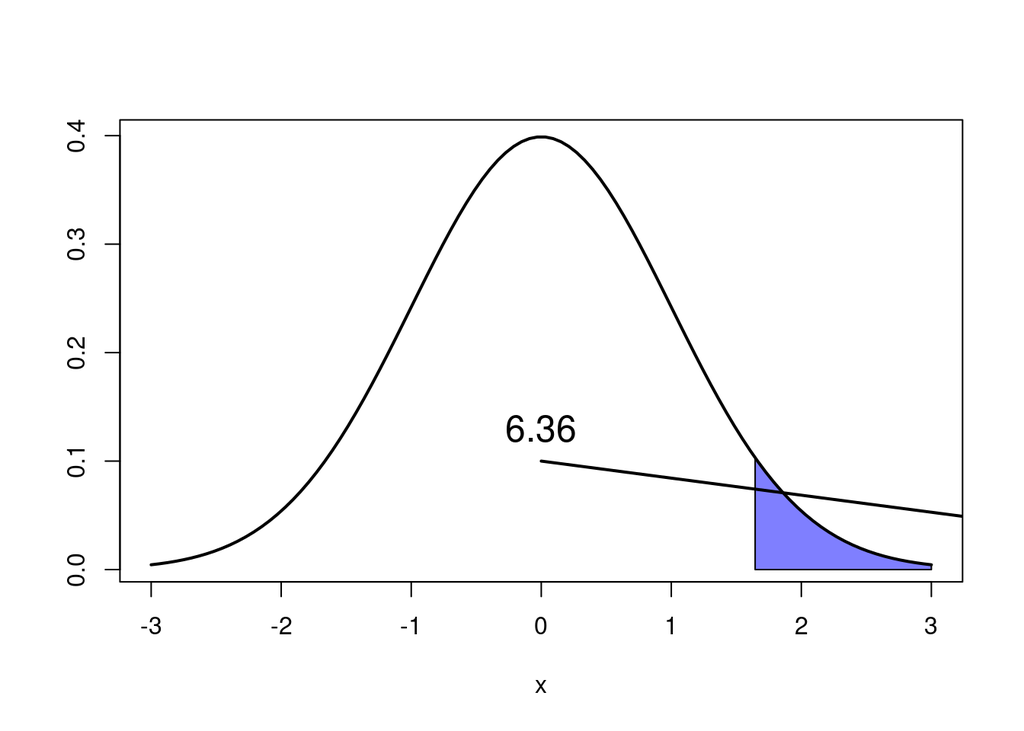

```r
curve_area(mean = 0, sd = 1, lb = qnorm(0.95), lwd = 2, acolor = rgb(0, 0, 1, alpha = 0.5), z=6.36)
```

Al comparar con el valor p vemos se debe rechazar H0, ya que p es menor al valor de alpha. Al rechazar la hipótesis nula concluimos que más del 50% de de los paises tienen un grado de corrupción 3.

## Anova

Dado que la variable principal de estudio en nuestro proyecto es la esperanza de vida, estamos llevando a cabo un análisis de las medias de esperanza de vida por región. Este análisis tiene como objetivo determinar similitudes o diferencias significativas entre las medias de esperanza de vida en distintas regiones, teniendo en cuenta factores culturales y económicos específicos de cada región. A continuación, se presentan las medias de esperanza de vida obtenidas:

```r
result <- aggregate(life_expectancy$`Life Expectancy World Bank`, by = list(life_expectancy$Region), FUN = mean)

colnames(result) <- c("Region", "Media_EsperanzaVidas")


print(result)
```

```
##                       Region Media_EsperanzaVidas
## 1        East Asia & Pacific             72.11389
## 2      Europe & Central Asia             77.37977
## 3  Latin America & Caribbean             75.09563
## 4 Middle East & North Africa             76.49884
## 5              North America             80.90106
## 6                 South Asia             71.60088
## 7         Sub-Saharan Africa             62.71578
```

A partir del resultado anterior, se observa una similitud entre las regiones “Middle East & North Africa”, “East Asia & Pacific” y “Europe & Central Asia”. Por lo tanto, el análisis de ANOVA se lleva a cabo específicamente en estas regiones con el objetivo de determinar si las medias de esperanza de vida son iguales o si al menos una difiere. En este contexto, se plantean las siguientes hipótesis:

```r
# Proceso de ANOVA

filtradoDeZonas <- life_expectancy %>%
  filter(life_expectancy$Region %in% c("Middle East & North Africa", "East Asia & Pacific", "Europe & Central Asia"))

print(filtradoDeZonas)
```

```
## # A tibble: 90 × 14
##    `Country Name` `Country Code` Region IncomeGroup  Year Life Expectancy Worl…¹
##    <chr>          <chr>          <chr>  <fct>       <dbl>                  <dbl>
##  1 Tuvalu         TUV            East … Upper midd…  2019                   65.2
##  2 Nauru          NRU            East … High income  2019                   65.2
##  3 San Marino     SMR            Europ… High income  2019                   65.2
##  4 Monaco         MCO            Europ… High income  2019                   65.2
##  5 Palau          PLW            East … Upper midd…  2019                   65.2
##  6 Northern Mari… MNP            East … High income  2019                   65.2
##  7 American Samoa ASM            East … Upper midd…  2019                   65.2
##  8 Tonga          TON            East … Upper midd…  2019                   70.9
##  9 Andorra        AND            Europ… High income  2019                   65.2
## 10 Marshall Isla… MHL            East … Upper midd…  2019                   65.2
## # ℹ 80 more rows
## # ℹ abbreviated name: ¹`Life Expectancy World Bank`
## # ℹ 8 more variables: `Prevelance of Undernourishment` <dbl>, CO2 <dbl>,
## #   `Health Expenditure %` <dbl>, `Education Expenditure %` <dbl>,
## #   Unemployment <dbl>, Corruption <dbl>, Sanitation <dbl>, Injuries <dbl>
```

```r
modelo_anova <- aov(lm(`Life Expectancy World Bank` ~ Region, data = filtradoDeZonas))

resumen_anova <- summary(modelo_anova)

print(resumen_anova)
```

```
##             Df Sum Sq Mean Sq F value   Pr(>F)
## Region       2  489.8   244.9   8.244 0.000526 ***
## Residuals   87 2584.2    29.7
## ---
## Signif. codes:  0 '***' 0.001 '**' 0.01 '*' 0.05 '.' 0.1 ' ' 1
```

Con base en los resultados obtenidos, se rechaza la hipótesis nula $H_0$. Por consiguiente, se lleva a cabo un análisis post-ANOVA con el propósito de comprender e identificar la naturaleza de esta diferencia.

```r
resumenTukey <- TukeyHSD(modelo_anova)


postAnova <- summary(resumenTukey)

#postAnova_formateado <- kable(as.data.frame(postAnova))


print(as.data.frame(resumenTukey$Region))
```

```
##                                                        diff        lwr      upr
## Europe & Central Asia-East Asia & Pacific         5.2658819  2.1276601 8.404104
## Middle East & North Africa-East Asia & Pacific    4.3849465  0.2848796 8.485013
## Middle East & North Africa-Europe & Central Asia -0.8809354 -4.6424257 2.880555
##                                                         p adj
## Europe & Central Asia-East Asia & Pacific        0.0003853253
## Middle East & North Africa-East Asia & Pacific   0.0331827430
## Middle East & North Africa-Europe & Central Asia 0.8424151580
```

Dado el post-anova, podemos asegurar que existe una diferencia significativa de las medias entre ‘Europe & Central Asia’ y ‘East Asia & Pacific’, y entre ‘Middle East & North Africa’ y ‘East Asia & Pacific’.

## Prueba de independencia entre dos variables categóricas

Hipótesis nula (Ho): Los países se encuentran distribuidos de manera equitativa entre las categorías de ingresos.

Hipótesis alternativa (H1): Los países NO se encuentran distribuidos de manera equitativa entre las categorías de ingresos.

### Categorias de ingresos

High income=1 Upper middle income=2 Lower middle income=3 Low income=4

```r
tabla_contingencia <- matrix(c(1, 57, 2, 49, 3, 45, 4, 23), nrow = 4, byrow = TRUE)

# Etiquetar las filas y columnas
colnames(tabla_contingencia) <- c("Cat_ingresos","Paises")

# Realizar el test de chi-cuadrado con simulación de Monte Carlo
resultado_chi_cuadrado <- chisq.test(tabla_contingencia)
# Imprimir los resultados
print(resultado_chi_cuadrado)
```

```
##
##  Pearson's Chi-squared test
##
## data:  tabla_contingencia
## X-squared = 6.4655, df = 3, p-value = 0.09103
```

Dado que 0.09103>0.05 no hay evidencia suficiente para rechazar la hipótesis nula a un nivel de significancia del 5%. Por lo tanto, no hay suficiente evidencia para decir que los países no se distribuyen de manera equitativa entre las categorías de ingresos.

## Regresión Lineal

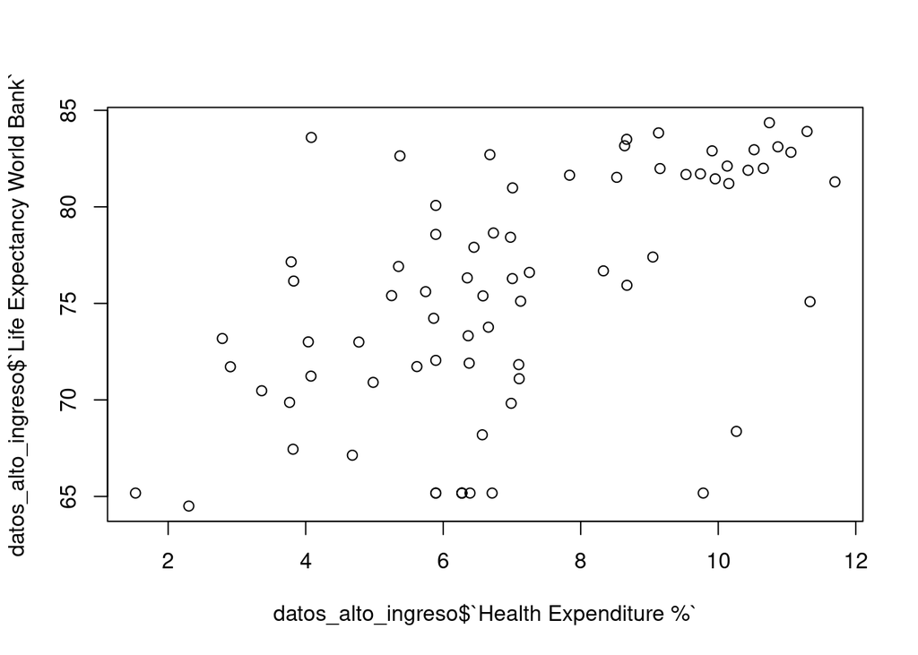

```r
df <- df %>%
  mutate(Grupo = case_when(
    Region %in% c("Europe & Central Asia", "East Asia & Pacific", "Middle East & North África") ~ "Alto Ingreso",
    Region == "Sub-Saharan Africa" ~ "Bajo Ingreso",
    TRUE ~ "Otro"
  ))
subgrupos <- split(df, df$Grupo)
datos_alto_ingreso <- subgrupos[["Alto Ingreso"]]
plot(datos_alto_ingreso$`Health Expenditure %`, datos_alto_ingreso$`Life Expectancy World Bank`)
```

```r
cor.test(datos_alto_ingreso$`Life Expectancy World Bank`, datos_alto_ingreso$`Health Expenditure %`)
```

```
##
##  Pearson's product-moment correlation
##
## data:  datos_alto_ingreso$`Life Expectancy World Bank` and datos_alto_ingreso$`Health Expenditure %`
## t = 5.751, df = 72, p-value = 1.999e-07
## alternative hypothesis: true correlation is not equal to 0
## 95 percent confidence interval:
##  0.3814457 0.6998264
## sample estimates:
##       cor
## 0.5610439
```

### **Prueba de correlación**

$H_0: ρ = 0$

$H_1: ρ \neq 0$

- **Coeficiente de correlación de Pearson (cor):** El valor del coeficiente de correlación de Pearson es 0.5610439. Este valor indica la fuerza y la dirección de la relación lineal entre las dos variables. En este caso, un valor de 0.5610439 sugiere una correlación positiva moderada entre las dos variables; a medida que una variable aumenta, la otra tiende a aumentar también.
- **Valor p (p-value):** El valor p asociado a la prueba de correlación es $1.999 \times 10^{-7}$, que es extremadamente bajo. Esto sugiere que la correlación observada es estadísticamente significativa, es decir, es poco probable que la correlación sea el resultado del azar.
- **Intervalo de confianza del 95% para la correlación:** El intervalo de confianza del 95% para la correlación va desde 0.3814457 a 0.6998264. Esto significa que podemos estar 95% seguros de que el verdadero valor de la correlación entre estas dos variables cae dentro de este intervalo.
- **Hipótesis alternativa:** La hipótesis alternativa indica que la verdadera correlación no es igual a cero. Dado que el valor p es muy bajo, se rechaza la hipótesis nula de que la correlación es cero.

En resumen, hay una correlación positiva significativa entre “Life Expectancy World Bank” y “Health Expenditure %”, y esta relación es moderada, según el coeficiente de correlación de Pearson.

###**Modelo de regresión lineal**

```r
Regresion <- lm(datos_alto_ingreso$`Life Expectancy World Bank` ~ datos_alto_ingreso$`Health Expenditure %` , data = datos_alto_ingreso)
summary(Regresion)
```

```
##
## Call:
## lm(formula = datos_alto_ingreso$`Life Expectancy World Bank` ~
##     datos_alto_ingreso$`Health Expenditure %`, data = datos_alto_ingreso)
##
## Residuals:
##     Min      1Q  Median      3Q     Max
## -14.168  -2.328   1.102   3.352  12.315
##
## Coefficients:
##                                           Estimate Std. Error t value Pr(>|t|)
## (Intercept)                                65.5079     1.8318  35.762   <2e-16
## datos_alto_ingreso$`Health Expenditure %`   1.4142     0.2459   5.751    2e-07
##
## (Intercept)                               ***
## datos_alto_ingreso$`Health Expenditure %` ***
## ---
## Signif. codes:  0 '***' 0.001 '**' 0.01 '*' 0.05 '.' 0.1 ' ' 1
##
## Residual standard error: 5.174 on 72 degrees of freedom
## Multiple R-squared:  0.3148, Adjusted R-squared:  0.3053
## F-statistic: 33.07 on 1 and 72 DF,  p-value: 1.999e-07
```

En la regresión lineal modelada, la ecuación del modelo es:

$$\text{Life Expectancy World Bank} =
65.5079 + 1.4142 \times \text{Health Expenditure %}$$

Interpretación: - **Intercepto (65.5079):** En el contexto del modelo, este valor representa el valor predicho de “Life Expectancy World Bank” cuando se desprecia el efecto de la variable explicativa “Health Expenditure %” o se mantiene constante.

- **Pendiente (1.4142):** Indica el cambio promedio en la variable de respuesta (“Life Expectancy World Bank”) por cada unidad de cambio en la variable explicativa (“Health Expenditure %”). En este caso, un aumento de una unidad en “Health Expenditure %”, % of PIB, se asocia, en promedio, con un aumento de 1.4142 unidades en “Life Expectancy World Bank”, la cual se mide en años. La dirección de la relación (positiva o negativa) depende del signo de la pendiente, y en este caso, como el coeficiente es positivo, hay una relación positiva entre las dos variables: a medida que aumenta el gasto en salud, se espera que la expectativa de vida también aumente.

Los valores de p asociados con cada coeficiente indican la significancia estadística de cada coeficiente. En este caso, ambos coeficientes tienen valores de p muy bajos ($< 0.05$), lo que sugiere que tanto el intercepto como la pendiente son estadísticamente significativos.

###**Test de Breusch-Pagan**

```r
bptest(Regresion)
```

```
##
##  studentized Breusch-Pagan test
##
## data:  Regresion
## BP = 0.018403, df = 1, p-value = 0.8921
```

- **Breusch-Pagan test (BP):** En este caso, el estadístico de prueba (BP) es 0.018403.
- **Grados de libertad (df):** El número de grados de libertad asociados con el estadístico de prueba es 1.
- **Valor p (p-value):** El valor p asociado al test de Breusch-Pagan es 0.8921.

**Interpretación:** El test de Breusch-Pagan se utiliza para evaluar la presencia de heterocedasticidad en los residuos de un modelo de regresión.

$H_0:$ La varianza de los errores es constante (homocedasticidad).

$H_1:$ La hipótesis alternativa es que la varianza de los errores no es constante (heterocedasticidad).

En este caso, dado que el valor p es alto (0.8921), no hay evidencia suficiente para rechazar la hipótesis nula de homocedasticidad. En otras palabras, no se encuentra evidencia estadística significativa de que la varianza de los errores sea diferente a lo largo de los niveles de la variable explicativa “Health Expenditure %”.

Por lo tanto, en términos prácticos, el resultado sugiere que el modelo de regresión no está mostrando signos significativos de heterocedasticidad según el test de Breusch-Pagan.

###**Test de normalidad de Shapiro-Wilk**

```r
Residuos<-residuals(Regresion)
shapiro.test(Residuos)
```

```
##
##  Shapiro-Wilk normality test
##
## data:  Residuos
## W = 0.9586, p-value = 0.0162
```

- **Estadístico de prueba (W):** En este caso, el estadístico de prueba de Shapiro-Wilk (W) es 0.9586.
- **Valor p (p-value):** El valor p asociado al test de Shapiro-Wilk es 0.0162.

**Interpretación:** El test de Shapiro-Wilk se utiliza para evaluar si los datos (en este caso, los residuos del modelo de regresión) siguen una distribución normal.

$H_0:$ Los residuos siguen una distribución normal. $H_1:$ Los residuos no siguen una distribución normal.

En este caso, el valor p es $0.0162$, que es menor que el nivel de significancia típicamente utilizado (como $0.05$). Por lo tanto, hay evidencia suficiente para rechazar la hipótesis nula de normalidad. Esto sugiere que los residuos no siguen una distribución normal.